# Reproducible Research: Peer Assessment 1

## Synopsis

This analysis looks at the weekend versus weekday activity of an individual as measured in steps over time. From the data I found that the weekend and weekday activity is different for this individual with both different daily patterns and different overall activity levels.

## Loading and preprocessing the data

This data was collected from a personal activity monitoring device worn by an anonymous individual collected at 5 minute intervals through out the day. The data consists of two months of data during the months of October and November, 2012 and include the number of steps taken in 5 minute intervals each day.

The data was loaded from the [course data](https://d396qusza40orc.cloudfront.net/repdata%2Fdata%2Factivity.zip) as provided by R. Peng.

### Load the data

The data was expanded from its original zip format from the operating system and then examined with operating system tools. It was found the be in CSV format with headers provided and it was read as is with headers.

```r
# Load supporting library and read in data
library(dplyr, warn.conflicts=FALSE)
StepsData <- read.csv("Data/activity.csv")
```

Overall the 17,568 observations were read with some NA data in the steps variable.

```r
# Basic summary
summary(StepsData)
```

```
##      steps                date          interval
##  Min.   :  0.00   2012-10-01:  288   Min.   :   0.0
##  1st Qu.:  0.00   2012-10-02:  288   1st Qu.: 588.8
##  Median :  0.00   2012-10-03:  288   Median :1177.5
##  Mean   : 37.38   2012-10-04:  288   Mean   :1177.5
##  3rd Qu.: 12.00   2012-10-05:  288   3rd Qu.:1766.2
##  Max.   :806.00   2012-10-06:  288   Max.   :2355.0
##  NA's   :2304     (Other)   :15840
```

```r
# First 10 rows
head(StepsData, 10)
```

```
##    steps       date interval
## 1     NA 2012-10-01        0
## 2     NA 2012-10-01        5
## 3     NA 2012-10-01       10
## 4     NA 2012-10-01       15
## 5     NA 2012-10-01       20
## 6     NA 2012-10-01       25
## 7     NA 2012-10-01       30
## 8     NA 2012-10-01       35
## 9     NA 2012-10-01       40
## 10    NA 2012-10-01       45
```

```r
# Random 10 rows
sample_n(StepsData, 10)
```

```
##       steps       date interval
## 1121     35 2012-10-04     2120
## 8968     NA 2012-11-01      315
## 4124      0 2012-10-15      735
## 12319   231 2012-11-12     1830
## 744       0 2012-10-03     1355
## 11706    NA 2012-11-10     1525
## 2865      0 2012-10-10     2240
## 15028     0 2012-11-22      415
## 2598      0 2012-10-10       25
## 2818     82 2012-10-10     1845
```

## Mean total number of steps taken per day?

The mean values are examined in 2 ways, a histogram of steps per day and the mean and median values of the overall data set.

#### Histogram of the total number of steps taken each day

A histogram of data with missing values skipped.

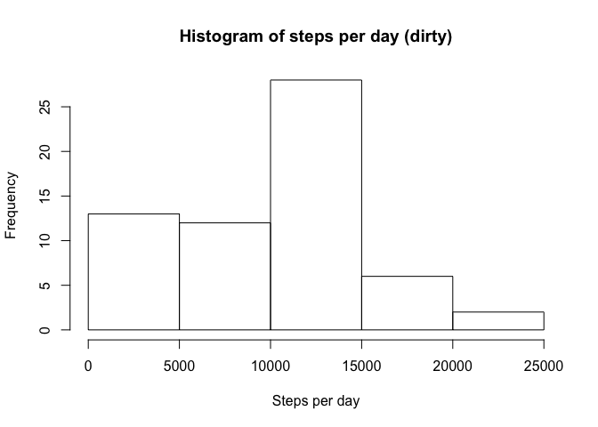

```r
RawSumStepsByDay <- StepsData %>% group_by(date) %>% summarize(stepsSum = sum(steps, na.rm=TRUE))
hist(RawSumStepsByDay$stepsSum, xlab="Steps per day", main="Histogram of steps per day (dirty)")
```

#### Mean and median total number of steps taken per day.

The original data (wih missing values skipped) has a mean of 9354 and a median of 10395.

```r
mean(RawSumStepsByDay$stepsSum)
```

```
## [1] 9354.23
```

```r
median(RawSumStepsByDay$stepsSum)
```

```
## [1] 10395
```

## What is the average daily activity pattern?

```r
RawSumStepsBy5Min <- StepsData %>% group_by(interval) %>% summarize(stepsSum = sum(steps, na.rm=TRUE), stepsMean = mean(steps, na.rm=TRUE))
as.integer(RawSumStepsBy5Min[which.max(RawSumStepsBy5Min$stepsMean),"interval"])
```

```
## [1] 835
```

```r
max(RawSumStepsBy5Min$stepsMean)
```

```
## [1] 206.1698
```

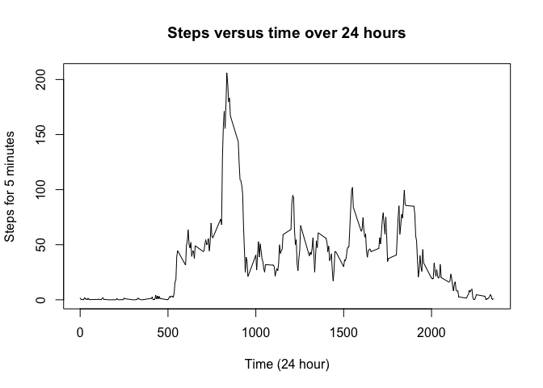

```r
plot(x = RawSumStepsBy5Min$interval, y = RawSumStepsBy5Min$stepsMean, type='l', xlab="Time (24 hour)", ylab="Steps for 5 minutes", main="Steps versus time over 24 hours")
```

## Imputing missing values

There are a number of days/intervals where there are missing values (coded as NA). The extent of the missing data was examined and the missing data was populated using the average across the complete data set for the corresponding interval.

Overall, there are 2304 periods with missing data that will be being populated.

```r
# Count of missing steps data
sum(is.na(StepsData$steps))
```

```
## [1] 2304
```

I created a cleaned data set by filling the NA values with the mean for the 5 minute interval across all days so that it could be compared with the original data.

```r
# Create new data set
find.stepsMean <- function (x) RawSumStepsBy5Min$stepsMean[match (x, RawSumStepsBy5Min$interval)]
CleanedStepsData <- StepsData %>%
      mutate(steps = ifelse(is.na(steps), find.stepsMean(interval),steps))
# Verify all NAs populated
sum(is.na(CleanedStepsData$steps))
```

```
## [1] 0
```

## Post cleanup data analysis

Comparing the data pre and post cleanup shows that the imputation can have a significant effect on the results. In this case, the post cleanup data show a more normal distribution.

#### Histogram of the total number of steps taken each day

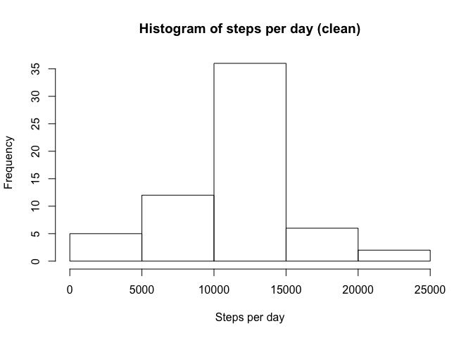

```r
CleanedSumStepsByDay <- CleanedStepsData %>% group_by(date) %>% summarize(stepsSum = sum(steps, na.rm=TRUE))
hist(CleanedSumStepsByDay$stepsSum,xlab="Steps per day", main="Histogram of steps per day (clean)")
```

#### Mean and median total number of steps taken per day.

The cleaned data (wih missing values replaced) has both a mean of 10766 and a median of 10766.

```r
mean(CleanedSumStepsByDay$stepsSum)
```

```
## [1] 10766.19
```

```r
median(CleanedSumStepsByDay$stepsSum)
```

```
## [1] 10766.19
```

## Differences in activity patterns between weekdays and weekends?

In comparing the weekend to weekday data, there are very different patterns of activity for this individual during the period of the data.

```r
is.weekend <- function (x) as.factor(ifelse(weekdays(x) %in% c("Saturday", "Sunday"), "Weekend", "Weekday"))
CleanedStepsData <- mutate (CleanedStepsData, weekend = is.weekend(as.Date(date)))
CleanedSumStepsByDay <- mutate (CleanedSumStepsByDay, weekend = is.weekend(as.Date(date)))
```

#### Panel plot showing a time series of the 5-minute interval versus the average number of steps taken over all weekday days and weekend days (y-axis).

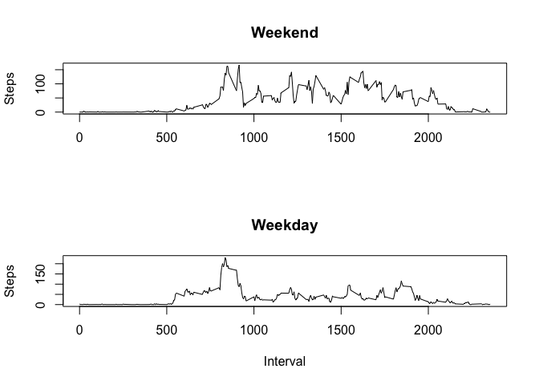

```r
CleanedSumStepsForWeekendBy5Min <- filter(CleanedStepsData, weekend == "Weekend") %>% group_by(weekend, interval) %>% summarize(stepsSum = sum(steps, na.rm=TRUE), stepsMean = mean(steps, na.rm=TRUE))
CleanedSumStepsForWeekdayBy5Min <- filter(CleanedStepsData, weekend == "Weekday") %>% group_by(weekend, interval) %>% summarize(stepsSum = sum(steps, na.rm=TRUE), stepsMean = mean(steps, na.rm=TRUE))
par(mfrow = c(2,1))
plot(x = CleanedSumStepsForWeekendBy5Min$interval, y = CleanedSumStepsForWeekendBy5Min$stepsMean, type='l', main="Weekend", ylab="Steps", xlab="")
plot(x = CleanedSumStepsForWeekdayBy5Min$interval, y = CleanedSumStepsForWeekdayBy5Min$stepsMean, type='l', main="Weekday",ylab="Steps", xlab="Interval")
```